# Pima Indian Diabetes Analysis

Stefany Ayala

# Introduction

The objective of this analysis is to explore, clean, and prepare the **Pima Indian Diabetes dataset** for modeling. This report demonstrates the application of data cleaning, visualization, and machine learning techniques in R. Additionally, we compare the performance of two algorithms to showcase modeling versatility.

# 1. Data Loading

We first load the data directly from a URL into R and inspect its structure.

```r
# Load necessary libraries
library(ggplot2)
library(OneR)
library(rpart)

# Load the dataset
url <- "https://drive.google.com/uc?id=1MvxSOTYHknWFIukVGaEzR79-cLX_JHMC&export=download"
diabetes <- read.csv(url)

# Inspect dataset structure
dim(diabetes)  # Dimensions of the dataset
```

```
## [1] 768   9
```

```r
attributes(diabetes)  # Attributes of the dataset
```

```
## $names
## [1] "Number.of.times.pregnant"
## [2] "Plasma.glucose.concentration.a.2.hours.in.an.oral.glucose.tolerance.test"
## [3] "Diastolic.blood.pressure"
## [4] "Triceps.skin.fold.thickness"
## [5] "X2.Hour.serum.insulin"
## [6] "Body.mass.index"
## [7] "Diabetes.pedigree.function"
## [8] "Age"
## [9] "Class.variable"
##
## $class
## [1] "data.frame"
##
## $row.names
```

[output cut: 43 more lines]

# 2. Data Exploration

## 2.1 Column Renaming

For better readability, we rename the columns.

```r
# Rename columns
colnames(diabetes) <- c('pregnant', 'glucose', 'bp', 'triceps', 'insulin', 'bmi',
                        'diabetes', 'age', 'target')
```

## 2.2 Initial Data Insights

We explore the dataset’s variables with histograms and basic descriptive statistics.

```
##     pregnant         glucose            bp            triceps
##  Min.   : 0.000   Min.   :  0.0   Min.   :  0.00   Min.   : 0.00
##  1st Qu.: 1.000   1st Qu.: 99.0   1st Qu.: 62.00   1st Qu.: 0.00
##  Median : 3.000   Median :117.0   Median : 72.00   Median :23.00
##  Mean   : 3.845   Mean   :120.9   Mean   : 69.11   Mean   :20.54
##  3rd Qu.: 6.000   3rd Qu.:140.2   3rd Qu.: 80.00   3rd Qu.:32.00
##  Max.   :17.000   Max.   :199.0   Max.   :122.00   Max.   :99.00
##     insulin           bmi           diabetes           age
##  Min.   :  0.0   Min.   : 0.00   Min.   :0.0780   Min.   :21.00
##  1st Qu.:  0.0   1st Qu.:27.30   1st Qu.:0.2437   1st Qu.:24.00
##  Median : 30.5   Median :32.00   Median :0.3725   Median :29.00
##  Mean   : 79.8   Mean   :31.99   Mean   :0.4719   Mean   :33.24
##  3rd Qu.:127.2   3rd Qu.:36.60   3rd Qu.:0.6262   3rd Qu.:41.00
##  Max.   :846.0   Max.   :67.10   Max.   :2.4200   Max.   :81.00
##      target
##  Min.   :0.000
##  1st Qu.:0.000
##  Median :0.000
##  Mean   :0.349
##  3rd Qu.:1.000
##  Max.   :1.000
```

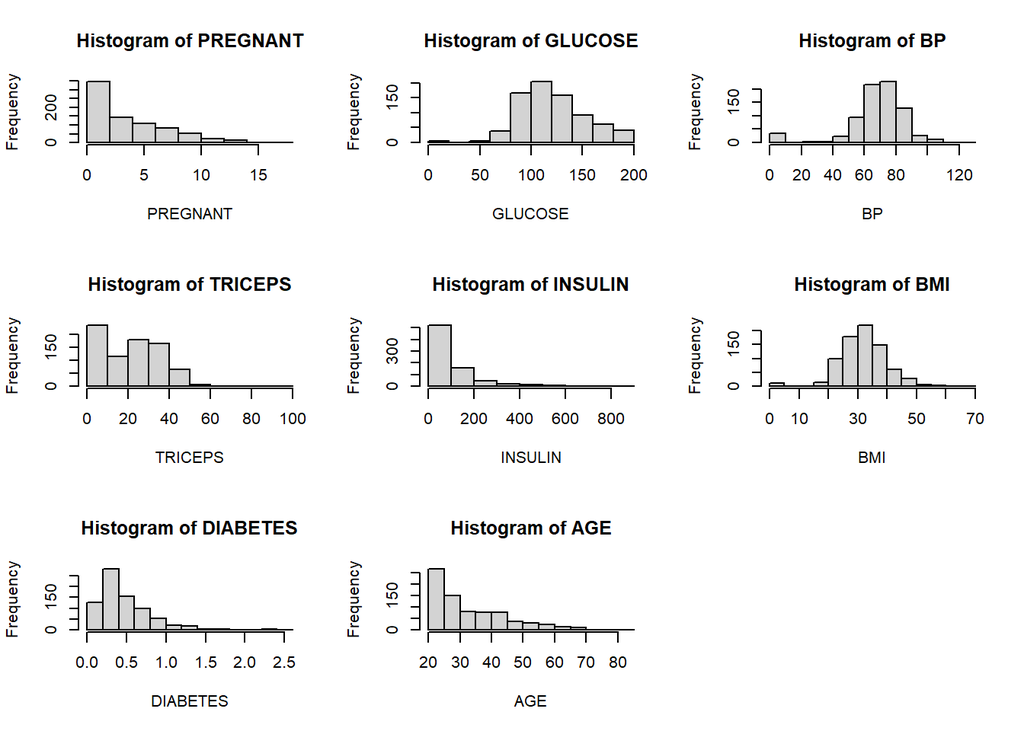

```r
# Visualize data distributions
par(mfrow = c(3, 3))
for (col in names(diabetes)[-9]) {
  hist(diabetes[[col]], main = paste("Histogram of", toupper(col)), xlab = toupper(col))
}

# Summarize descriptive statistics
summary(diabetes)
```

# 3. Data Cleaning

## 3.1 Detecting and Handling Outliers

Outliers are detected using Tukey’s method and replaced with NA.

```r
# Handle outliers
clean_data <- diabetes
for (col in names(diabetes)[-9]) {
  outliers <- boxplot.stats(diabetes[[col]])$out
  clean_data[[col]] <- ifelse(diabetes[[col]] %in% outliers, NA, diabetes[[col]])
}
```

## 3.2 Imputing Missing Values

Missing values are replaced with the mean of each variable.

```r
# Impute missing values with the mean
clean_data <- as.data.frame(lapply(clean_data, function(x)
  ifelse(is.na(x), mean(x, na.rm = TRUE), x)))

# Verify no missing values remain
sum(is.na(clean_data))
```

```
## [1] 0
```

# 4. Data Preparation

The cleaned dataset is split into training (80%) and testing (20%) sets.

```r
# Split data
set.seed(123)
train_indices <- sample(1:nrow(clean_data), size = 0.8 * nrow(clean_data))
TrainData <- clean_data[train_indices, ]
TestData <- clean_data[-train_indices, ]
```

# 5. Modeling

Interpretation

- **OneR Model:**

This simple model provides interpretable rules based on a single attribute, which can be ideal for quick insights. The model’s performance metrics indicate its effectiveness in this context.

- **Decision Tree Model:**

The confusion matrix reveals the strengths and weaknesses in classification. Decision Trees, though more complex, offer better granularity in predictions.

By comparing the results of both models, we gain insights into the trade-offs between model simplicity and performance.

## 5.1 OneR Model

We train a OneR model to identify the best attribute and evaluate its performance.

```r
# Train a OneR model
one_r_model <- OneR(target ~ ., data = TrainData, verbose = TRUE)
```

```
##
##     Attribute Accuracy
## 1 * glucose   75.24%
## 2   age       67.1%
## 3   pregnant  65.8%
## 4   bmi       65.47%
## 5   insulin   65.15%
## 6   bp        64.82%
## 6   triceps   64.82%
## 6   diabetes  64.82%
## ---
## Chosen attribute due to accuracy
## and ties method (if applicable): '*'
```

```r
# Summarize the model
summary(one_r_model)
```

```
##
## Call:
## OneR.formula(formula = target ~ ., data = TrainData, verbose = TRUE)
##
## Rules:
## If glucose = (55.9,84.6] then target = 0
## If glucose = (84.6,113]  then target = 0
## If glucose = (113,142]   then target = 0
## If glucose = (142,170]   then target = 1
## If glucose = (170,199]   then target = 1
##
## Accuracy:
## 462 of 614 instances classified correctly (75.24%)
##
## Contingency table:
##       glucose
## target (55.9,84.6] (84.6,113] (113,142] (142,170] (170,199] Sum
##    0          * 51      * 178     * 129        31         9 398
##    1             1         36        75      * 56      * 48 216
##    Sum          52        214       204        87        57 614
## ---
## Maximum in each column: '*'
##
## Pearson's Chi-squared test:
## X-squared = 149.67, df = 4, p-value < 2.2e-16
```

```r
# Predict on test data
one_r_predictions <- predict(one_r_model, TestData)

# Evaluate the model
one_r_eval <- eval_model(one_r_predictions, TestData)
```

```
##
## Confusion matrix (absolute):
##           Actual
## Prediction   0   1 UNSEEN Sum
##     0       87  28      0 115
##     1       14  24      0  38
##     UNSEEN   1   0      0   1
##     Sum    102  52      0 154
##
## Confusion matrix (relative):
##           Actual
## Prediction    0    1 UNSEEN  Sum
##     0      0.56 0.18   0.00 0.75
##     1      0.09 0.16   0.00 0.25
##     UNSEEN 0.01 0.00   0.00 0.01
##     Sum    0.66 0.34   0.00 1.00
##
## Accuracy:
## 0.7208 (111/154)
##
## Error rate:
## 0.2792 (43/154)
##
## Error rate reduction (vs. base rate):
## 0.1731 (p-value = 0.07215)
```

```r
one_r_eval
```

```
## $correct_instances
## [1] 111
##
## $total_instances
## [1] 154
##
## $conf_matrix
##           Actual
## Prediction  0  1 UNSEEN
##     0      87 28      0
##     1      14 24      0
##     UNSEEN  1  0      0
```

## 5.2 Decision Tree Model

As a comparison, we train a Decision Tree model and evaluate its performance.

```r
# Train a decision tree model
tree_model <- rpart(target ~ ., data = TrainData, method = "class")

# Predict on test data (specifying 'type = "class"' to get class labels)
tree_predictions <- predict(tree_model, TestData, type = "class")

# Confusion matrix
confusion_matrix <- table(Predicted = tree_predictions, Actual = TestData$target)
confusion_matrix
```

```
##          Actual
## Predicted  0  1
##         0 81 24
##         1 21 28
```

# 6. Results and Evaluation

## 6.1 OneR Model Results

The OneR model was trained on the dataset to identify the best single predictor of the target variable. The OneR model achieves an accuracy of **75.24%** based on the rule for the `glucose` variable. The model divides the `glucose` variable into ranges and predicts the target variable based on these ranges.

The confusion matrix is as follows:

```r
# Display evaluation metrics
one_r_eval
```

```
## $correct_instances
## [1] 111
##
## $total_instances
## [1] 154
##
## $conf_matrix
##           Actual
## Prediction  0  1 UNSEEN
##     0      87 28      0
##     1      14 24      0
##     UNSEEN  1  0      0
```

From the confusion matrix, we can see that the OneR model has some false positives and false negatives, but it is still fairly accurate for this task.

## 6.2 Decision Tree Model Results

To compare the performance of a more complex algorithm, a Decision Tree model was trained. Its predictions on the test data are evaluated using a confusion matrix:

```r
# Confusion matrix for Decision Tree model
confusion_matrix <- table(tree_predictions, TestData$target)

# Display confusion matrix
confusion_matrix
```

```
##
## tree_predictions  0  1
##                0 81 24
##                1 21 28
```

The Decision Tree model is capable of capturing more complex relationships in the data compared to the OneR model, though it also has some misclassifications.

# Final thoughs

Both models show reasonable accuracy, but the OneR model is simpler and more interpretable. The Decision Tree model, while more complex, may be more suitable for capturing non-linear patterns. Further experimentation, such as cross-validation and hyperparameter tuning, could lead to improved performance.